# Unsupervised Learning

Algorithmik und Statistik 1

Sascha Metzger - 1910837830

2019-01-01 (updated: 2020-02-23)

```r
library(caret)
library(GGally)
```

```r
library(corrplot)
pacman::p_load(tidyverse, ggfortify)
data <- read_csv(file = "data/wisc.csv")
```

# Unsupervised Learning

Für dieses Blatt verwenden wir den kompletten Wisconsin Datensatz `wisc.csv`. Wir betrachten aber nicht die Vorhersage der Klasse (meist entfernen wir die Spalte “class”), sondern versuchen Features zu analysiseren.

```r
head(data)
```

```
## # A tibble: 6 x 11
##   class radius texture perimeter  area smoothness compactness concavity concave
##   <chr>  <dbl>   <dbl>     <dbl> <dbl>      <dbl>       <dbl>     <dbl>   <dbl>
## 1 M       18.0    10.4     123.  1001      0.118       0.278     0.300   0.147
## 2 M       20.6    17.8     133.  1326      0.0847      0.0786    0.0869  0.0702
## 3 M       19.7    21.2     130   1203      0.110       0.160     0.197   0.128
## 4 M       11.4    20.4      77.6  386.     0.142       0.284     0.241   0.105
## 5 M       20.3    14.3     135.  1297      0.100       0.133     0.198   0.104
## 6 M       12.4    15.7      82.6  477.     0.128       0.17      0.158   0.0809
## # … with 2 more variables: symmetry <dbl>, fractal <dbl>
```

```r
glimpse(data)
```

```
## Observations: 569
## Variables: 11
## $ class       <chr> "M", "M", "M", "M", "M", "M", "M", "M", "M", "M", "M", "M…
## $ radius      <dbl> 17.990, 20.570, 19.690, 11.420, 20.290, 12.450, 18.250, 1…
## $ texture     <dbl> 10.38, 17.77, 21.25, 20.38, 14.34, 15.70, 19.98, 20.83, 2…
## $ perimeter   <dbl> 122.80, 132.90, 130.00, 77.58, 135.10, 82.57, 119.60, 90.…
## $ area        <dbl> 1001.0, 1326.0, 1203.0, 386.1, 1297.0, 477.1, 1040.0, 577…
## $ smoothness  <dbl> 0.11840, 0.08474, 0.10960, 0.14250, 0.10030, 0.12780, 0.0…
## $ compactness <dbl> 0.27760, 0.07864, 0.15990, 0.28390, 0.13280, 0.17000, 0.1…
## $ concavity   <dbl> 0.30010, 0.08690, 0.19740, 0.24140, 0.19800, 0.15780, 0.1…
## $ concave     <dbl> 0.14710, 0.07017, 0.12790, 0.10520, 0.10430, 0.08089, 0.0…
## $ symmetry    <dbl> 0.2419, 0.1812, 0.2069, 0.2597, 0.1809, 0.2087, 0.1794, 0…
## $ fractal     <dbl> 0.07871, 0.05667, 0.05999, 0.09744, 0.05883, 0.07613, 0.0…
```

```r
classes <- data %>% group_by(class) %>% tally()
classes
```

```
## # A tibble: 2 x 2
##   class     n
##   <chr> <int>
## 1 B       357
## 2 M       212
```

```r
meanOfNumCols <- lapply(data[2:ncol(data)], mean)
meanOfNumCols
```

```
## $radius
## [1] 14.12729
##
## $texture
## [1] 19.28965
##
## $perimeter
## [1] 91.96903
##
## $area
## [1] 654.8891
##
## $smoothness
## [1] 0.09636028
##
## $compactness
## [1] 0.104341
##
## $concavity
## [1] 0.08879932
##
## $concave
## [1] 0.04891915
##
## $symmetry
## [1] 0.1811619
##
## $fractal
## [1] 0.06279761
```

```r
sdOfNumCols <- lapply(data[2:ncol(data)], sd)
sdOfNumCols
```

```
## $radius
## [1] 3.524049
##
## $texture
## [1] 4.301036
##
## $perimeter
## [1] 24.29898
##
## $area
## [1] 351.9141
##
## $smoothness
## [1] 0.01406413
##
## $compactness
## [1] 0.05281276
##
## $concavity
## [1] 0.07971981
##
## $concave
## [1] 0.03880284
##
## $symmetry
## [1] 0.02741428
##
## $fractal
## [1] 0.007060363
```

```r
corr <- cor(data[2:ncol(data)])
corr
```

```
##                 radius     texture  perimeter       area  smoothness
## radius       1.0000000  0.32378189  0.9978553  0.9873572  0.17058119
## texture      0.3237819  1.00000000  0.3295331  0.3210857 -0.02338852
## perimeter    0.9978553  0.32953306  1.0000000  0.9865068  0.20727816
## area         0.9873572  0.32108570  0.9865068  1.0000000  0.17702838
## smoothness   0.1705812 -0.02338852  0.2072782  0.1770284  1.00000000
## compactness  0.5061236  0.23670222  0.5569362  0.4985017  0.65912322
## concavity    0.6767636  0.30241783  0.7161357  0.6859828  0.52198377
## concave      0.8225285  0.29346405  0.8509770  0.8232689  0.55369517
## symmetry     0.1477412  0.07140098  0.1830272  0.1512931  0.55777479
## fractal     -0.3116308 -0.07643718 -0.2614769 -0.2831098  0.58479200
##             compactness concavity   concave   symmetry     fractal
## radius        0.5061236 0.6767636 0.8225285 0.14774124 -0.31163083
## texture       0.2367022 0.3024178 0.2934641 0.07140098 -0.07643718
## perimeter     0.5569362 0.7161357 0.8509770 0.18302721 -0.26147691
## area          0.4985017 0.6859828 0.8232689 0.15129308 -0.28310981
## smoothness    0.6591232 0.5219838 0.5536952 0.55777479  0.58479200
## compactness   1.0000000 0.8831207 0.8311350 0.60264105  0.56536866
## concavity     0.8831207 1.0000000 0.9213910 0.50066662  0.33678336
## concave       0.8311350 0.9213910 1.0000000 0.46249739  0.16691738
## symmetry      0.6026410 0.5006666 0.4624974 1.00000000  0.47992133
## fractal       0.5653687 0.3367834 0.1669174 0.47992133  1.00000000
```

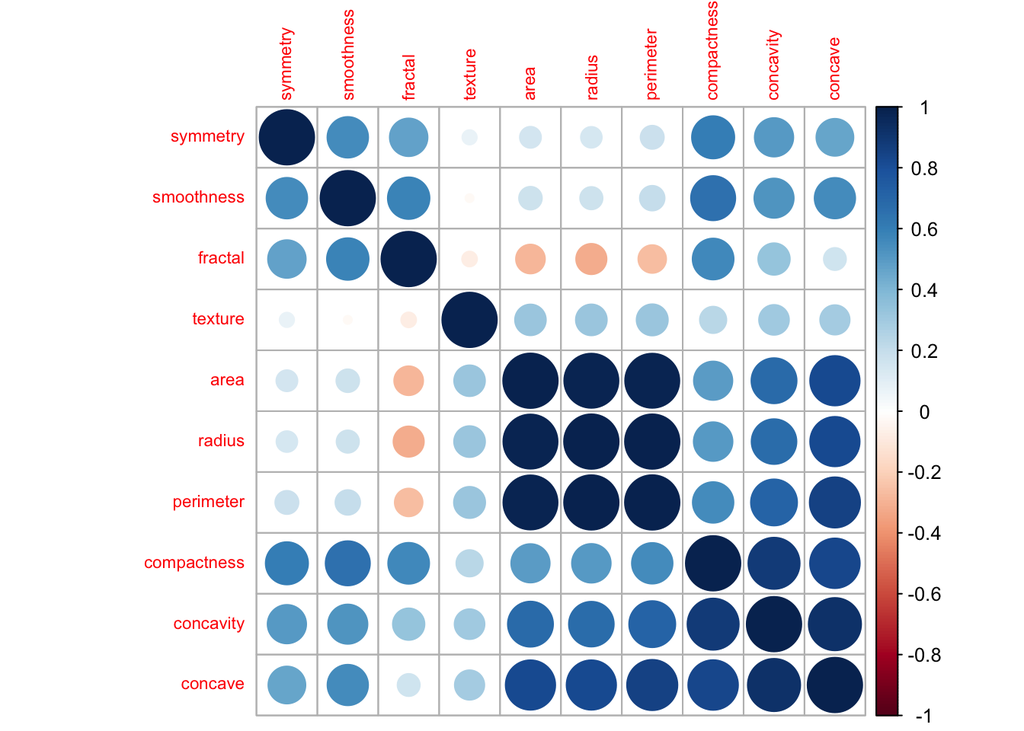

```r
corMatMy <- cor(data[2:ncol(data)])
corrplot(corMatMy, order = "hclust", tl.cex = 0.7)
```

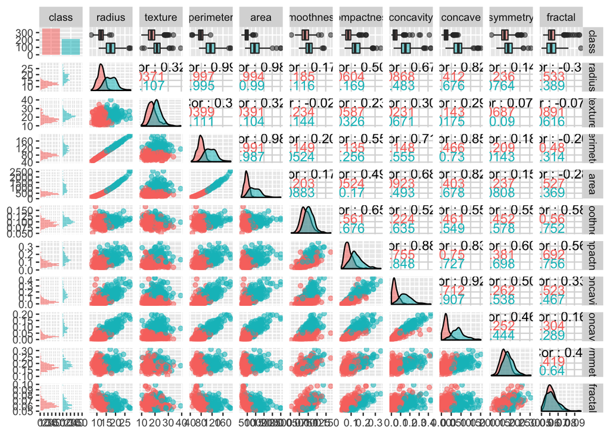

```r
ggp = ggpairs(data[1:11], aes(color=class, alpha=0.4), progress = F)
suppressMessages(print(ggp))
```

## Aufgabe 1 EDA [5 Punkte]

[x] Wie viele Beobachtungen haben eine gutartige oder bösartige Diagnose ? M steht für “malignant / bösartig” und somit gibt es 212 bösartige Diagnosen. B steht für “benign / gutartig” und hiervon gibt es 357 Beobachtungen.

[x] Was ist der Mittelwert der einzelnen numerischen Spalten? $radius [1] 14.12729 $texture [1] 19.28965 $perimeter [1] 91.96903 $area [1] 654.8891 $smoothness [1] 0.09636028 $compactness [1] 0.104341 $concavity [1] 0.08879932 $concave [1] 0.04891915 $symmetry [1] 0.1811619 $fractal [1] 0.06279761

[x] Was ist die sd jeder der numerischen Spalten? $radius [1] 3.524049 $texture [1] 4.301036 $perimeter [1] 24.29898 $area [1] 351.9141 $smoothness [1] 0.01406413 $compactness [1] 0.05281276 $concavity [1] 0.07971981 $concave [1] 0.03880284 $symmetry [1] 0.02741428 $fractal [1] 0.007060363

[x] Was können wir bis jetzt daraus schliessen? (Welche Variablen sind besonders hoch korreliert?) Es gibt viele Variablen welche miteinander korreliert sind. Allerdings sind die hoch korrelierenden Merkmale häufig redundant (bspw. radius & area). Sollten wir später Ergebnisse treffen, müssen wir dies berücksichtigen. Nur weil diese Merkmale hoch korrelieren beudetet es nicht, dass sie uns helfen ein Ergebnis vorherzusagen.

## Aufgabe 2 PCA [15 Punkte]

[x] Erstelle ein PCA-Modell und gib das Summary aus. (Hinweis, ohne Skalierung/Normalisierung) Funktion `princomp` (Hinweis: wir verwenden sowohl princomp als auch pr.comp - Unterschied in der Hilfe)

```r
wdbc.data <- as.matrix(data[2:ncol(data)])

wdbc.pcov <- princomp(wdbc.data, scores = TRUE)
summary(wdbc.pcov)
```

```
## Importance of components:
##                             Comp.1       Comp.2       Comp.3       Comp.4
## Standard deviation     352.4394674 4.1992044183 3.8620710633 2.278780e-01
## Proportion of Variance   0.9997376 0.0001419224 0.0001200487 4.179473e-07
## Cumulative Proportion    0.9997376 0.9998795174 0.9999995661 1.000000e+00
##                              Comp.5       Comp.6       Comp.7       Comp.8
## Standard deviation     3.299528e-02 2.244103e-02 1.496997e-02 1.069091e-02
## Proportion of Variance 8.762351e-09 4.053243e-09 1.803676e-09 9.199123e-10
## Cumulative Proportion  1.000000e+00 1.000000e+00 1.000000e+00 1.000000e+00
##                              Comp.9      Comp.10
## Standard deviation     6.717126e-03 2.735101e-03
## Proportion of Variance 3.631482e-10 6.020933e-11
## Cumulative Proportion  1.000000e+00 1.000000e+00
```

[x] Erstelle einen Plot mit der funktion `biplot`.

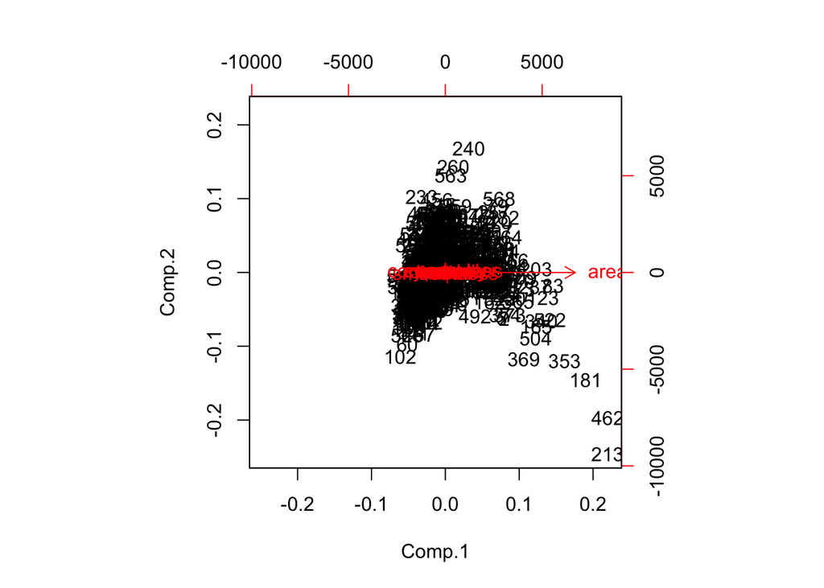

```r
suppressWarnings(biplot(wdbc.pcov))
```

[x] Interpretiere den Plot, was fällt auf? (Einfluss der ersten beiden Hauptkomponenten?) Es fällt auf, dass die ersten beiden Hauptkomponenten unterschiedliche Maßeinheiten haben. Dies kann zu verstärkten Varianzen führen und die Interpretation erschweren.

[x] Plotte die Varianz erklärt für die Hauptkomponenten. Was fällt dabei auf (seltsames Ergebnis wird erwartet).

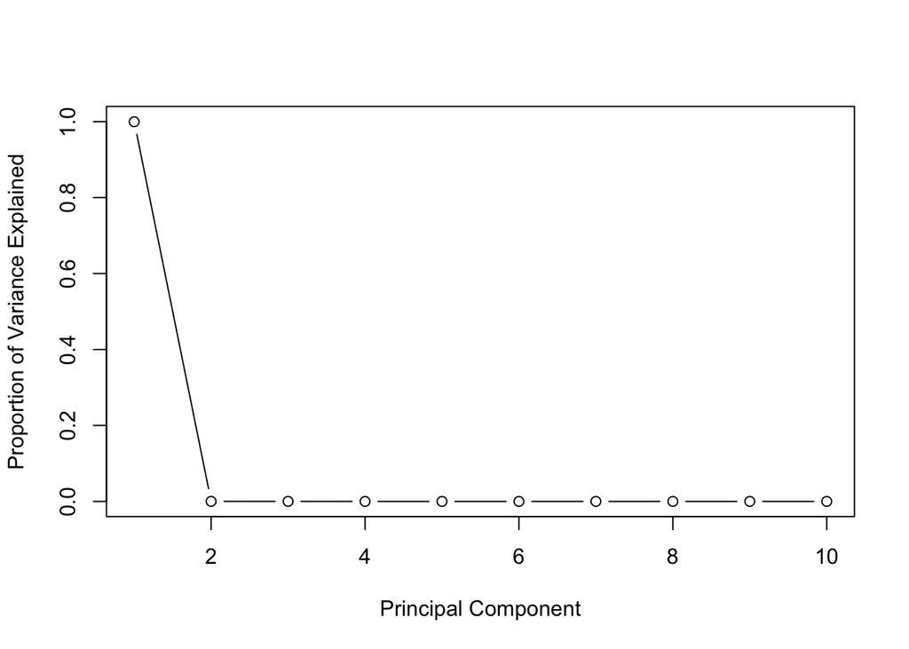

```r
pr.cvar <- wdbc.pcov$sdev ^ 2
pve_cov <- pr.cvar/sum(pr.cvar)
plot(pve_cov, xlab = "Principal Component", ylab = "Proportion of Variance Explained", ylim = c(0, 1), type = "b")
```

```r
# Es fällt dabei auf, dass bereits ein Großteil der Varianz mit Comp.1 erklärt werden kann.
```

### Durchführung von PCA mit Korrelationsmatrix:

Wenn die Korrelationsmatrix zur Berechnung der Eigenwerte und Eigenvektoren(Hauptkomponenten) verwendet wird, verwenden wir die Funktion prcomp().

[x] Erstelle eine PCA mit *center* und *scale* mit der Funktion prcomp und interpretiere den output.

```r
wdbc.pr <- prcomp(wdbc.data, scale = TRUE, center = TRUE)
summary(wdbc.pr)
```

```
## Importance of components:
##                           PC1    PC2     PC3    PC4     PC5     PC6     PC7
## Standard deviation     2.3406 1.5870 0.93841 0.7064 0.61036 0.35234 0.28299
## Proportion of Variance 0.5479 0.2519 0.08806 0.0499 0.03725 0.01241 0.00801
## Cumulative Proportion  0.5479 0.7997 0.88779 0.9377 0.97495 0.98736 0.99537
##                            PC8     PC9    PC10
## Standard deviation     0.18679 0.10552 0.01680
## Proportion of Variance 0.00349 0.00111 0.00003
## Cumulative Proportion  0.99886 0.99997 1.00000
```

```r
# Die ersten drei Componenten können 0.88779 Anteile der Varianz erklären. Mit den unskalierten Daten konnte bereits PC1 den Großteil der Varianz erklären.
```

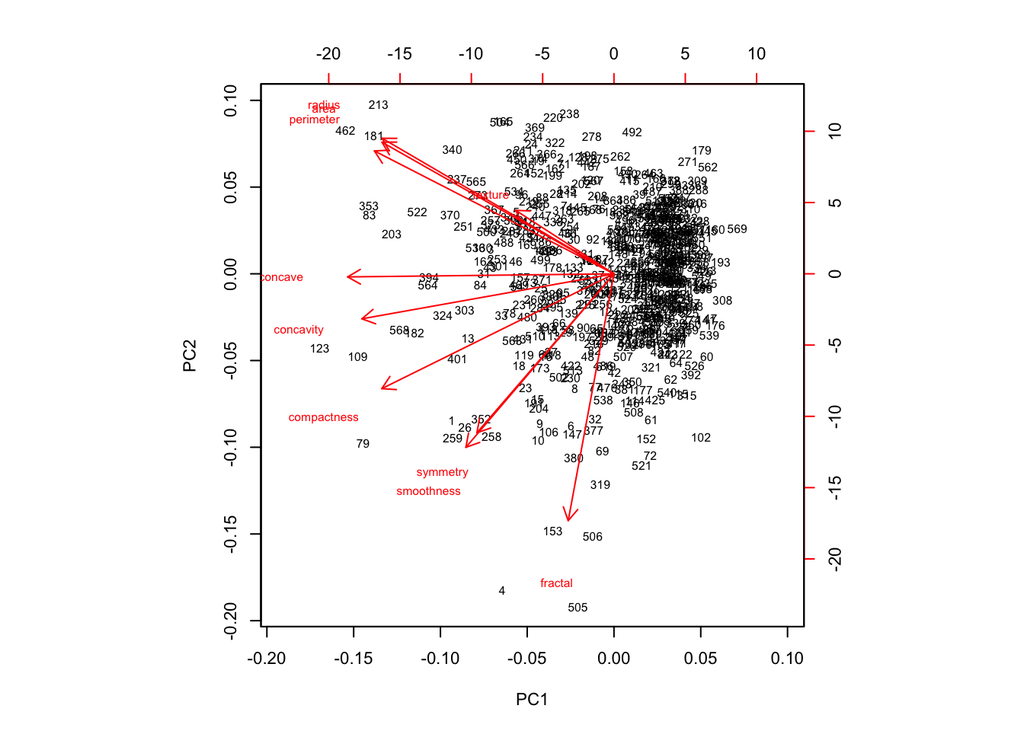

```r
cex.before <- par("cex")
par(cex = 0.7)
biplot(wdbc.pr)
```

[x] Erstelle einen Scatterplot der ersten beiden Hauptkomponenten und füge die Klasse als Variable hinzu. Sind die Klassen separiert? Wenn ja, was können wir daraus schliessen?

[figure not shown]

```r
# Create diagnosis vector
diagnosis <- as.numeric(data$class == "M")
plot(wdbc.pr$x[, c(1, 2)], col = (diagnosis + 1), xlab = "PC1", ylab = "PC2")
legend(x="topleft", pch=1, col = c("red", "black"), legend = c("B", "M"))
```

```r
# Im Plot können wir erkennen, dass es eine klare Trennung der Diagnose (M oder B) gibt.
```

### Berechnen Sie den Anteil der erklärten Varianz

[x] Berechnen Sie den Anteil der erklärten Varianz wie vorher und beantworten Sie wie viele Komponenten sind notwendig um 95% der Varianz zu erklären. (Hinweis `cumsum`)

```r
pr.var <- wdbc.pr$sdev ^ 2
names(pr.var) <- names(pr.cvar)
pve <- pr.var/sum(pr.var)
cumsum(pve)
```

```
##    Comp.1    Comp.2    Comp.3    Comp.4    Comp.5    Comp.6    Comp.7    Comp.8
## 0.5478588 0.7997302 0.8877917 0.9376926 0.9749465 0.9873607 0.9953692 0.9988582
##    Comp.9   Comp.10
## 0.9999718 1.0000000
```

```r
# Mit 5 Komponenten können wir 0.97 Anteile der Varianz erklären.
```

### Variation der PCA, Entfernen korrelierter Prädiktoren

Lassen Sie uns die gleiche Übung mit einem zweiten df durchführen, bei der wir die hoch korrelierten Prädiktoren (Corr>0.95) entfernt haben. (Center+Scale=T)

[x] Plotten Sie den Screeplot und interpretieren Sie die loadings.

```r
wdbc_cor <- colnames(data)[findCorrelation(corr, cutoff = 0.95, verbose = TRUE)]
```

```
## Compare row 3  and column  1 with corr  0.998
##   Means:  0.566 vs 0.472 so flagging column 3
## Compare row 1  and column  4 with corr  0.987
##   Means:  0.493 vs 0.455 so flagging column 1
## All correlations <= 0.95
```

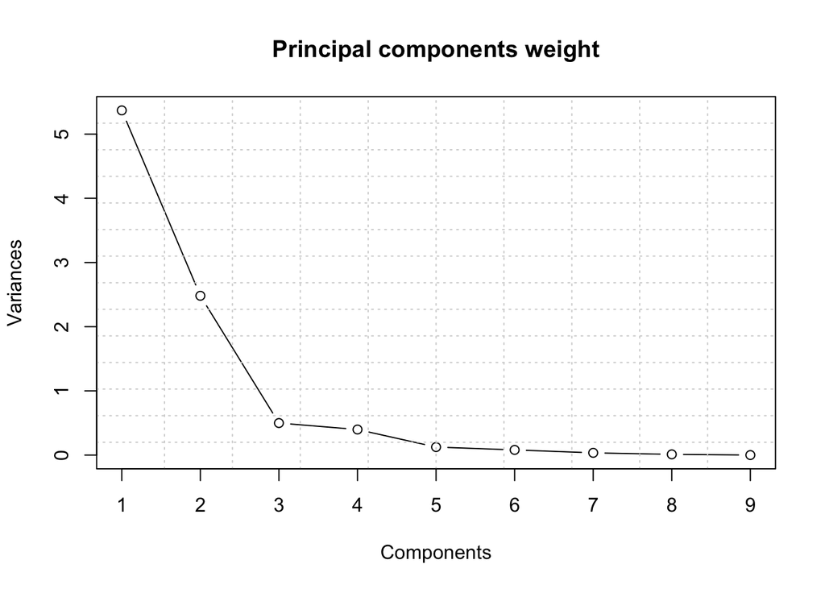

```r
wdbc_cor <- data[, which(!colnames(data) %in% wdbc_cor)]

cancer.pca <- prcomp(wdbc_cor, center=TRUE, scale=TRUE)
plot(cancer.pca, type="l", main='')
grid(nx = 10, ny = 14)
title(main = "Principal components weight", sub = NULL, xlab = "Components")
box()
```

```r
summary(cancer.pca)
```

```
## Importance of components:
##                           PC1    PC2     PC3     PC4     PC5     PC6     PC7
## Standard deviation     2.3173 1.5752 0.70643 0.63103 0.35339 0.28355 0.18690
## Proportion of Variance 0.5966 0.2757 0.05545 0.04424 0.01388 0.00893 0.00388
## Cumulative Proportion  0.5966 0.8723 0.92780 0.97204 0.98591 0.99485 0.99873
##                            PC8     PC9
## Standard deviation     0.10559 0.01680
## Proportion of Variance 0.00124 0.00003
## Cumulative Proportion  0.99997 1.00000
```

```r
# Mit den ersten beiden Komponenten können 87% der Varianz erklärt werden. Mit 6 Komponenten sind es schon 99%.
```

[x] Plotten wir die ersten beiden Hauptkomponenten als Scatterplot und “färben” nach der Klasse. Sind die Klassen separiert?

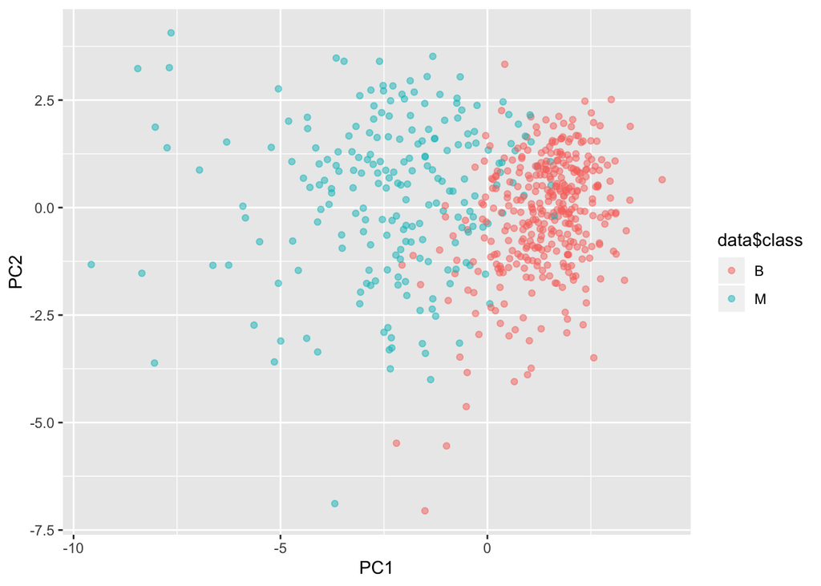

```r
pca_df <- as.data.frame(cancer.pca$x)
ggplot(pca_df, aes(x=PC1, y=PC2, col=data$class)) + geom_point(alpha=0.5)
```

```r
# Die Klassen sind nicht sehr gut separiert. Dies ist auch klar, da die ersten beiden Komponenten nur 87% der Varianz erklären.
```

[x] Um zu veranschaulichen, welche Variablen den größten Einfluss auf die ersten 2 Komponenten haben (Verwenden wir `autoplot` aus dem ggfortify package)

[figure not shown]

```r
autoplot(cancer.pca, data = data,  colour = 'class', loadings = FALSE, loadings.label = TRUE, loadings.colour = "blue")
```

[x] Als Abschluss verwenden wir ggpairs um die ersten 3 Komponenten zu visualisieren. Was können wir daraus ablesen?

```r
# Code intentionally Given
df_pcs <- cbind(as_tibble(data$class), as_tibble(cancer.pca$x))
GGally::ggpairs(df_pcs, columns = 2:4, ggplot2::aes(color = value))

# Wir können ablesen, dass PC1 und PC2 die Klassen "b" und "m" nur zu einem gewissen Teil trennen. Dies lässt sich auch wieder damit erklären, dass die durch diese beiden Komponenten erklärte Varianz nicht ausreichend groß ist.
```

[output not shown]